# Text Mining I

Published

October 23, 2023

# Introduction

Welcome to the second practical of the week!

The aim of this practical is to introduce you to text pre-processing and regular expressions.

In this practical, you will learn:

- Visualize the most frequent words in a data set using a word cloud and a bar plot.
- How to prepare and pre-process your text data.
- Use regular expressions to retrieve structured information from text.

```r
library(tidyverse) # as always :)
library(tidytext)  # for text mining
library(tm)        # needed for wordcloud
library(wordcloud) # to create pretty word clouds
library(SnowballC) # for Porter's stemming algorithm
```

# Preparation & Pre-process

## Text data set

We are going to use the following data set in this practical.

- **A data set with reviews of computers**.  
  This data set is annotated using aspect-based sentiment analysis. Aspect-based sentiment analysis is a text analysis technique that categorizes data by specific aspects and identifies the sentiment attributed to each one. You can download the data as a text file here. The original source is [here](https://www.cs.uic.edu/~liub/FBS/sentiment-analysis.html).

Each row of the file has the following format:

```
screen[-1], picture quality[-1] ## When the screen was n't contracting or glitching the overall picture quality was poor to fair .
```

The aspects are shown before `##`, the review is shown after `##`.

## Visualization

**1. Use the `read_delim` function from the `readr` package to read data from the `computer.txt` file.**

```r
computer_531 <- read_delim(
  file = "data/computer.txt",
  delim = "\n",
  col_names = "review"
)
head(computer_531)
```

```
# A tibble: 6 × 1
  review
  <chr>
1 ## I purchased this monitor because of budgetary concerns .
2 inexpensive[+1][a] ## This item was the most inexpensive 17 inch monitor avai…
3 monitor[-1] ## My overall experience with this monitor was very poor .
4 screen[-1], picture quality[-1] ## When the screen was n't contracting or gli…
5 monitor[-1], picture quality[-1] ## I 've viewed numerous different monitor m…
6 screen[-1] ## A week out of the box and I began to see slight contractions of…
```

**2. `wordcloud` is a function from the `wordcloud` package, which plots cool word clouds based on word frequencies in a given data set. Use this function to plot the 50 most frequent words with a minimum frequency of 5 using your data set. wordcloud will directly tokenize your documents.**

Check the help file of `wordcloud` function (e.g., `?wordcloud`) to see how to specify the arguments.

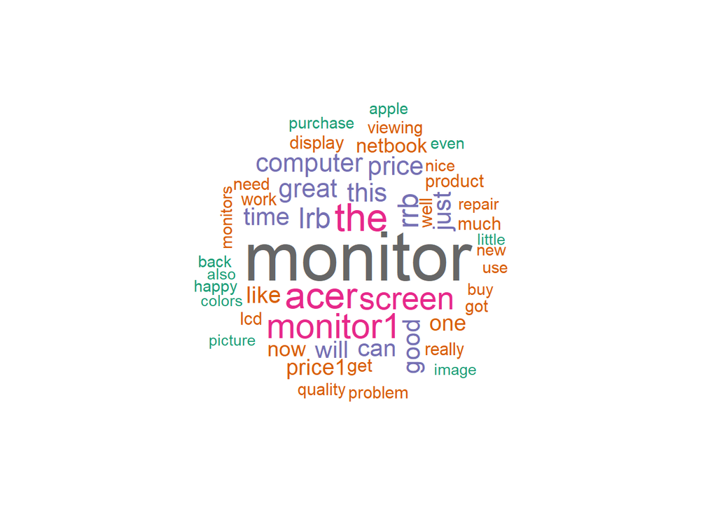

```r
wordcloud(
  words = computer_531$review,
  min.freq = 5,
  max.words = 50,
  random.order = FALSE,
  colors = brewer.pal(8, "Dark2")
)
```

Another way to visualize the term frequencies is using a barplot. For this we need to convert the data to a tidy format (where each word is a different row) and count the number of occurrences of each word. See the diagram below.

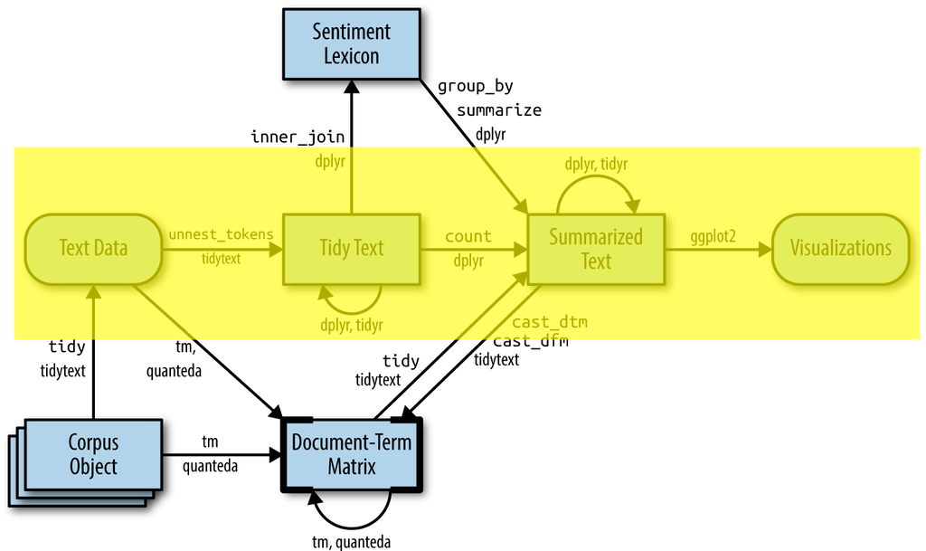

**3. Use `unnest_tokens` function from `tidytext` package to break the text into individual tokens (a process called [tokenization](https://en.wikipedia.org/wiki/Lexical_analysis#Tokenization)) and use `head` function to see its first several rows.**

Hint: `unnest_tokens(data, output column name, input column name)`

```r
# tokenize texts
comp_words <- computer_531 |>
  unnest_tokens(word, review)

# check the resulting tokens
head(comp_words)
```

```
# A tibble: 6 × 1
  word
  <chr>
1 i
2 purchased
3 this
4 monitor
5 because
6 of
```

**4. Use functions from the `dplyr` package (e.g., `count`, `arrange`) to select the most frequent 30 tokens and plot a bar chat using `ggplot`.**

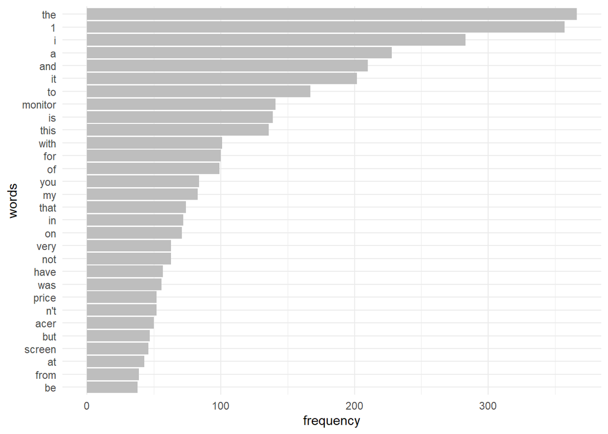

```r
comp_words |>
  # count the frequency of each word
  count(word) |>
  # arrange the words by its frequency in descending order
  arrange(desc(n)) |>
  # select the top 30 most frequent words
  head(30) |>
  # make a bar plot (reorder words by their frequencies)
  ggplot(aes(x = n, y = reorder(word, n))) +
  geom_col(fill="gray") +
  labs(x = "frequency", y="words") +
  theme_minimal()
```

```r
# Here you see that many of the top words are *stop words*.
# In the next part of the practical, we will learn how to proceed
# with pre-processing and remove the stop words!
```

**5. Remove the stop words from the tokenized data frame and plot a new bar chat.**

Hint: Use `anti_join` function to filter the `stop_words` from the `tidytext` package. `stop_words` is a dataset with stop words. By using anti_join, you keep only the words in the first dataset that *are not* in the `stop_words` dataset. Check the help file if you want further information on either one (e.g., `?anti_join`, `?stop_words`).

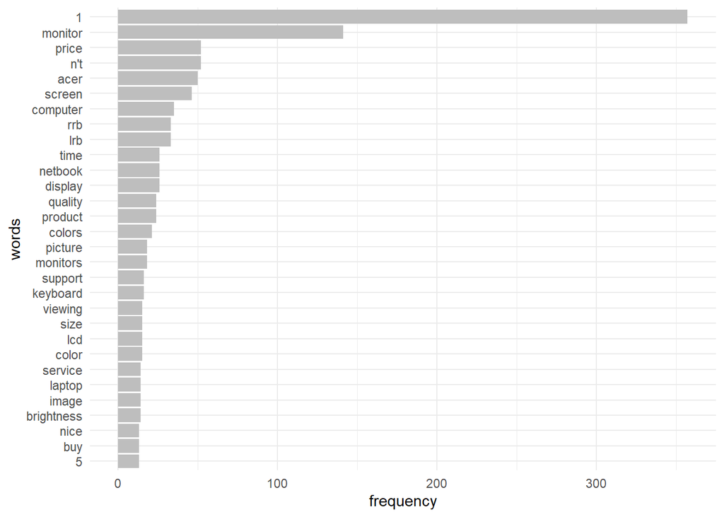

```r
comp_words_no_stop <-
  comp_words |>
  # remove stop words
  anti_join(stop_words)
comp_words_no_stop |>
  # count the frequency of each word
  count(word) |>
  # arrange the words by its frequency in descending order
  arrange(desc(n)) |>
  # select the top 30 most frequent words
  head(30) |>
  # make a bar plot (reorder words by their frequencies)
  ggplot(aes(x = n, y = reorder(word, n))) +
  geom_col(fill="gray") +
  labs(x = "frequency", y="words") +
  theme_minimal()
```

**6. You can always adjust your stopwords list. Create a custom list of stopwords `df_stopwords` by modifying the `stop_words`, adding new words (e.g., ‘buy’), and removing some of the current words listed (e.g., ‘order’). Then use `df_stopwords` in the `anti_join` function and check the plot.**

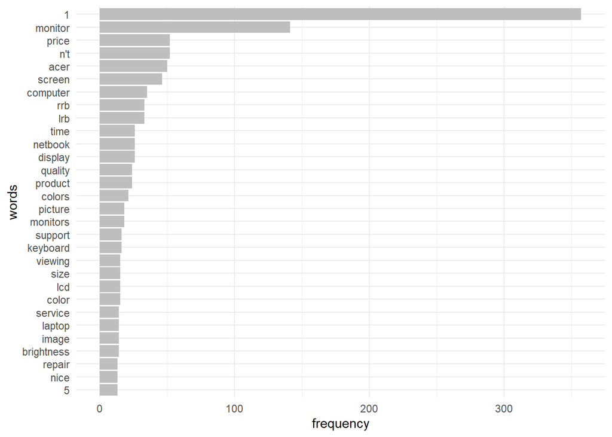

```r
# R code here
df_stopwords <-
  stop_words |>
  filter(!word %in% c("order", "ordered", "ordering", "orders")) |>
  rbind(tibble(word = c("buy", "online"), lexicon = c("Me", "Me")))

# remove stop words
comp_words_no_stop_modified <-
  comp_words |>
  anti_join(df_stopwords)
comp_words_no_stop_modified |>
  # count the frequency of each word
  count(word) |>
  # arrange the words by its frequency in descending order
  arrange(desc(n)) |>
  # select the top 30 most frequent words
  head(30) |>
  # make a bar plot (reorder words by their frequencies)
  ggplot(aes(x = n, y = reorder(word, n))) +
  geom_col(fill="gray") +
  labs(x = "frequency", y="words") +
  theme_minimal()
```

**7. When we deal with text, often documents contain different versions of one base word, called a stem. SnowballC is a package based on the famous Porter’s stemming algorithm that collapses words into their stem. Use the `getStemLanguages` function to find out how many languages this package supports.**

```r
getStemLanguages()
```

```
 [1] "arabic"     "basque"     "catalan"    "danish"     "dutch"
 [6] "english"    "finnish"    "french"     "german"     "greek"
[11] "hindi"      "hungarian"  "indonesian" "irish"      "italian"
[16] "lithuanian" "nepali"     "norwegian"  "porter"     "portuguese"
[21] "romanian"   "russian"    "spanish"    "swedish"    "tamil"
[26] "turkish"
```

**8. Applying stemming on your data frame and save the results in a new column. Show the top 30 most frequent stemmed words in a bar plot.**

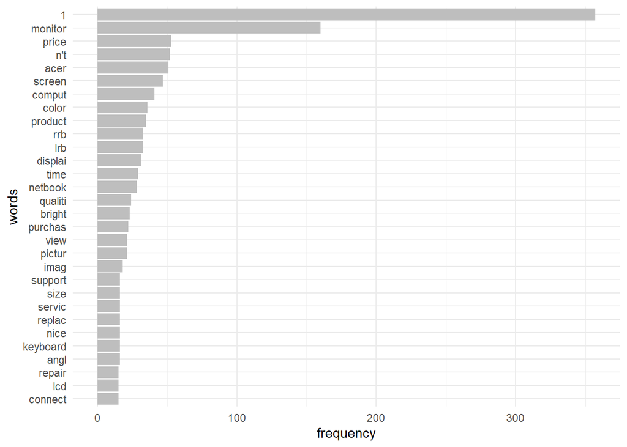

```r
comp_words_stemming <-
  comp_words_no_stop_modified |>
  mutate(stem = wordStem(word))

comp_words_stemming |>
  # count the frequency of each word
  count(stem) |>
  # arrange the words by its frequency in descending order
  arrange(desc(n)) |>
  # select the top 30 most frequent words
  head(30) |>
  # make a bar plot (reorder words by their frequencies)
  ggplot(aes(x = n, y = reorder(stem, n))) +
  geom_col(fill="gray") +
  labs(x = "frequency", y="words") +
  theme_minimal()
```

# Regular expressions

**9. Use regular expressions (regex) to find the reviews in `computer_531`, which contain words *“Monitor” or “monitor”*, *“memory” or “Memory”*, and *“Delivery” or “delivery”*. See how many reviews contain each pair of words.**

Hint: One of many different ways to achieve this is as follows:

1. Use `str_detect` function from `stringr` package to find the presence of patterns of your interest. See the lecture slide if you are unsure how to specify the *regex*. You can try different regex here: https://regexr.com/
2. Use `filter` function to only retain the ones that contain the patterns. You can write in one line such as `filter(str_detect(input vector, regex))`.
3. Count the number of reviews that contain each pattern.

```r
# reviews containing "Monitor" or "monitor"
reviews_mon <- computer_531 |>
  filter(str_detect(review, "[Mm]onitor"))

# reviews containing "memory" or "Memory"
reviews_mem <- computer_531 |>
  filter(str_detect(review, "[Mm]emory"))

# reviews containing "Delivery" or "delivery"
reviews_del <- computer_531 |>
  filter(str_detect(review, "[Dd]elivery"))

# compare the occurrence of each pair of words
kwords    <- c("Monitor", "Memory", "Delivery")
nr_kwords <- c(nrow(reviews_mon), nrow(reviews_mem), nrow(reviews_del))

tibble(kwords, nr_kwords)
```

```
# A tibble: 3 × 2
  kwords   nr_kwords
  <chr>        <int>
1 Monitor        105
2 Memory           5
3 Delivery         3
```

**10. Compare `str_detect`, `str_extract`, `str_subset` and `str_match` functions from the `stringr` package to check which words appear before “monitor” in the reviews from the `computer_531` data set.**

What does the regular expression `(\\w+) ([Mm]onitor)` match to? You can explore it using https://regexr.com

```r
## Detect
head(str_detect(computer_531$review, "(\\w+) ([Mm]onitor)"))
```

```
[1]  TRUE  TRUE  TRUE FALSE  TRUE FALSE
```

```r
## Extract
head(str_extract(computer_531$review, "(\\w+) ([Mm]onitor)"))
```

```
[1] "this monitor"      "inch monitor"      "this monitor"
[4] NA                  "different monitor" NA
```

```r
## Subset
head(str_subset(computer_531$review, "(\\w+) ([Mm]onitor)"))
```

```
[1] "## I purchased this monitor because of budgetary concerns ."
[2] "inexpensive[+1][a] ## This item was the most inexpensive 17 inch monitor available to me at the time I made the purchase ."
[3] "monitor[-1] ## My overall experience with this monitor was very poor ."
[4] "monitor[-1], picture quality[-1] ## I 've viewed numerous different monitor models since I 'm a college student and this particular monitor had as poor of picture quality as any I 've seen ."
[5] "## I sent it back and now will search for a better quality monitor ."
[6] "monitor[-1], colors[-1] ## I used this monitor for 2 years and now it shows a mixture of various colors and de-focused text ."
```

```r
## Match (Useful with capture groups)
head(str_match(computer_531$review, "(\\w+) ([Mm]onitor)"))
```

```
     [,1]                [,2]        [,3]
[1,] "this monitor"      "this"      "monitor"
[2,] "inch monitor"      "inch"      "monitor"
[3,] "this monitor"      "this"      "monitor"
[4,] NA                  NA          NA
[5,] "different monitor" "different" "monitor"
[6,] NA                  NA          NA
```

```r
# The regular expression `(\\w+) ([Mm]onitor)` matches any word,
# followed by a space, followed by either Monitor or monitor.
# - str_detect: returns T/F if the match is found or not
# - str_extract: returns the match if it is found (NA otherwise)
# - str_subset: returns the observations for which a match has been found
# - str_match: returns the match (split into groups) and NA otherwise
```

**11. You can also use `str_extract_all` and `str_match_all` to extract all matches. Use either of these functions to see all of the fully capitalized words in the first 10 reviews.**

```r
# use str_extract_all
str_extract_all(computer_531$review[1:10], '\\b[A-Z]+\\b', simplify = TRUE)
```

```
      [,1] [,2] [,3]
 [1,] "I"  ""   ""
 [2,] "I"  ""   ""
 [3,] ""   ""   ""
 [4,] ""   ""   ""
 [5,] "I"  "I"  "I"
 [6,] "A"  "I"  ""
 [7,] ""   ""   ""
 [8,] "I"  "I"  ""
 [9,] "I"  ""   ""
[10,] "I"  ""   ""
```

```r
# The output from `str_extract_all`/`str_match_all` is a list,
# which can be pasted together by using `sapply`. In the case
# of str_extract_all, it can be parsed in different columns
# using simplify = TRUE.
```

**12. In order to separate aspects and sentiments in the reviews from the `computer_531` data, let’s first use a regular expression to extract the characters at the beginning of each line until `##`. Do this for only the first 20 reviews.**

Hint: Use the `str_extract` function such that `str_extract(first 20 reviews, regex)`.

Hint 2: The symbol `^` matches to “start of line”. The symbol `.` matches anything. The symbol `*` indicates that the previous character can appear any number of times (including zero times). e.g., `.*` matches to all characters (until the end of the line); `.*R` matches to all characters until a capital R is found.

```r
str_extract(computer_531[[1]][1:20], "^.*##")
```

```
 [1] "##"                                  "inexpensive[+1][a] ##"
 [3] "monitor[-1] ##"                      "screen[-1], picture quality[-1] ##"
 [5] "monitor[-1], picture quality[-1] ##" "screen[-1] ##"
 [7] "Display[-1] ##"                      "monitor[-1] ##"
 [9] "##"                                  "##"
[11] "##"                                  "##"
[13] "##"                                  "monitor[-1], colors[-1] ##"
[15] "##"                                  "size[+1] ##"
[17] "computer[+1], quality[+1] ##"        "##"
[19] "keyboard[+1], color[+1] ##"          "speed[+1], memory[+1] ##"
```

Hint: Use `mutate()` and `str_extract()` (e.g., `mutate(cleaned_review = str_extract(...), aspect_sentiment = str_extract(...))`).

```r
computer_531 <- computer_531 |>
  mutate(cleaned_review = str_extract(review,"##.*$"),
         aspect_sentiment = str_extract(review,"^.*##"))

# check the newly added columns
head(computer_531[-1])
```

```
# A tibble: 6 × 2
  cleaned_review                                                aspect_sentiment
  <chr>                                                         <chr>
1 ## I purchased this monitor because of budgetary concerns .   ##
2 ## This item was the most inexpensive 17 inch monitor availa… inexpensive[+1]…
3 ## My overall experience with this monitor was very poor .    monitor[-1] ##
4 ## When the screen was n't contracting or glitching the over… screen[-1], pic…
5 ## I 've viewed numerous different monitor models since I 'm… monitor[-1], pi…
6 ## A week out of the box and I began to see slight contracti… screen[-1] ##
```

```r
# for an even cleaner version you can use regex's lookbehind and lookahead
# features to drop the ## parts:
computer_531 <- computer_531 |>
  mutate(cleaned_review = str_extract(review,"(?<=##).*$"),
         aspect_sentiment = str_extract(review,"^.*(?=##)"))

# check the newly added columns
head(computer_531[-1])
```

```
# A tibble: 6 × 2
  cleaned_review                                                aspect_sentiment
  <chr>                                                         <chr>
1 " I purchased this monitor because of budgetary concerns ."   ""
2 " This item was the most inexpensive 17 inch monitor availab… "inexpensive[+1…
3 " My overall experience with this monitor was very poor ."    "monitor[-1] "
4 " When the screen was n't contracting or glitching the overa… "screen[-1], pi…
5 " I 've viewed numerous different monitor models since I 'm … "monitor[-1], p…
6 " A week out of the box and I began to see slight contractio… "screen[-1] "
```

**14. Run the following code below to create a new column `sentiment` with the values `positive`, `negative` and `neutral`. The code assigns `neutral` in case when there is no aspect in the corresponding column or the sum of scores is equal to zero, and it assigns `negative` (`positive`) when the sum score is lower (higher) than zero.**

```r
# define sum_list function which adds the scores
sum_list <- function(list_values) {
  sum(as.numeric(list_values))
}

computer_531 <- computer_531 |>
  # sentiment_score: extract the scores and sum them using the sum_list function
  mutate(sentiment_score = map_dbl(str_extract_all(aspect_sentiment, "[-|\\+]\\d+"), sum_list),
                               # assign negative when score < 0
         sentiment = case_when(sentiment_score < 0 ~ "negative",
                               # assign negative when score > 0
                               sentiment_score > 0 ~ "positive",
                               # assign neutral otherwise
                               TRUE ~ "neutral"))

head(computer_531)
```

```
# A tibble: 6 × 5
  review               cleaned_review aspect_sentiment sentiment_score sentiment
  <chr>                <chr>          <chr>                      <dbl> <chr>
1 ## I purchased this… " I purchased… ""                             0 neutral
2 inexpensive[+1][a] … " This item w… "inexpensive[+1…               1 positive
3 monitor[-1] ## My o… " My overall … "monitor[-1] "                -1 negative
4 screen[-1], picture… " When the sc… "screen[-1], pi…              -2 negative
5 monitor[-1], pictur… " I 've viewe… "monitor[-1], p…              -2 negative
6 screen[-1] ## A wee… " A week out … "screen[-1] "                 -1 negative
```

**15. What is the most positive review?**

```r
computer_531 |>
  arrange(sentiment_score) |>
  tail(1) |>
  pull(cleaned_review)
```

```
[1] " After much delay I received my Acer Netbook Aspire One and I can teell you I am very satisfied with this computer , is very pretty , well finished , high quality , so quiet , not heated than other netbook or at least I think it is within in normal ranges , the keyboard is very smooth and very …
```